# CW2_Data Analytics

Exploratory Data Analysis & Machine Learning

Priyanshu Thakur

May 05, 2026

# 1 Setup

## 1.1 Installing & Loading Packages

The analysis uses a range of packages for data handling, visualisation, and modelling. The snippet below installs any that are missing and loads them all silently.

```r
packages = c("nnet", "caret", "class", "gmodels", "C50",
              "klaR", "e1071", "kernlab", "caTools", "ggplot2", "infotheo",
              "dplyr", "reshape2", "knitr", "scales")

new.packages =packages[!(packages %in% installed.packages()[, "Package"])]
if (length(new.packages)) install.packages(new.packages)

invisible(lapply(packages, library, character.only = TRUE))
```

## 1.2 Importing the Dataset

The [UCI Car Evaluation dataset](https://archive.ics.uci.edu/ml/datasets/Car+Evaluation) contains **1000 records** with six categorical features and one target variable (`acceptability`).

```r
source_file ="car.csv"
df = read.csv(source_file)
```

# 2 Exploratory Data Analysis & Data Preparation

## 2.1 Initial Inspection

```r
head(df, 10)
```

|  | buying | maint | doors | persons | lug_boot | safety | acceptability |
| --- | --- | --- | --- | --- | --- | --- | --- |
| 1 | vhigh | low | 5more | 4 | small | low | unacc |
| 2 | high | vhigh | 3 | 2 | med | low | unacc |
| 3 | vhigh | high | 4 | 4 | big | med | unacc |
| 4 | high | vhigh | 5more | 4 | med | low | unacc |
| 5 | vhigh | high | 5more | 2 | med | high | unacc |
| 6 | med | vhigh | 4 | more | small | med | unacc |
| 7 | med | med | 4 | 2 | big | med | unacc |
| 8 | low | vhigh | 2 | more | big | high | acc |
| 9 | med | low | 4 | 4 | small | med | acc |
| 10 | med | low | 4 | more | big | med | good |

```r
cat("Dimensions:", nrow(df), "rows", ncol(df), "columns\n")
```

```
## Dimensions: 1000 rows 7 columns
```

```r
cat("Missing values:", sum(is.na(df)), "\n\n")
```

```
## Missing values: 0
```

```r
df =data.frame(lapply(df, factor))

summary(df)
```

```
##    buying      maint       doors     persons     lug_boot    safety
##  high :270   high :242   2    :243   2   :321   big  :341   high:330
##  low  :238   low  :248   3    :246   4   :343   med  :324   low :337
##  med  :257   med  :259   4    :259   more:336   small:335   med :333
##  vhigh:235   vhigh:251   5more:252
##  acceptability
##  acc  :231
##  good : 41
##  unacc:693
##  vgood: 35
```

```r
str(df)
```

```
## 'data.frame':    1000 obs. of  7 variables:
##  $ buying       : Factor w/ 4 levels "high","low","med",..: 4 1 4 1 4 3 3 2 3 3 ...
##  $ maint        : Factor w/ 4 levels "high","low","med",..: 2 4 1 4 1 4 3 4 2 2 ...
##  $ doors        : Factor w/ 4 levels "2","3","4","5more": 4 2 3 4 4 3 3 1 3 3 ...
##  $ persons      : Factor w/ 3 levels "2","4","more": 2 1 2 2 1 3 1 3 2 3 ...
##  $ lug_boot     : Factor w/ 3 levels "big","med","small": 3 2 1 2 2 3 1 1 3 1 ...
##  $ safety       : Factor w/ 3 levels "high","low","med": 2 2 3 2 1 3 3 1 3 3 ...
##  $ acceptability: Factor w/ 4 levels "acc","good","unacc",..: 3 3 3 3 3 3 3 1 1 2 ...
```

> **Key takeaway:** There are no missing values. All variables are categorical, which makes this an ideal dataset for classification algorithms that handle factors natively (e.g., C5.0, Naive Bayes).

## 2.2 Cross-Tabulations

`table()` lets us cross-tabulate categorical variables and spot patterns quickly.

### 2.2.1 Buying vs. Acceptability

```r
df$acceptability =factor(df$acceptability, levels = c("unacc", "acc", "good", "vgood"))
df$buying = factor(df$buying, levels = c("vhigh", "high", "med", "low"))

knitr::kable(
  addmargins(table(df$buying, df$acceptability)),
  caption = "Buying vs. Acceptability"
)
```

Buying vs. Acceptability

|  | unacc | acc | good | vgood | Sum |
| --- | --- | --- | --- | --- | --- |
| vhigh | 195 | 40 | 0 | 0 | 235 |
| high | 198 | 72 | 0 | 0 | 270 |
| med | 162 | 68 | 14 | 13 | 257 |
| low | 138 | 51 | 27 | 22 | 238 |
| Sum | 693 | 231 | 41 | 35 | 1000 |

> **Insight:** Low-price cars are more commonly rated as acceptable, suggesting price can be a key driver of acceptability.

### 2.2.2 Maintenance vs Acceptability

```r
df$maint = factor(df$maint, levels = c("vhigh", "high", "med", "low"))

knitr::kable(
  addmargins(table(df$maint, df$acceptability)),
  caption = "Maintenace vs. Acceptability"
)
```

Maintenace vs. Acceptability

|  | unacc | acc | good | vgood | Sum |
| --- | --- | --- | --- | --- | --- |
| vhigh | 212 | 39 | 0 | 0 | 251 |
| high | 170 | 68 | 0 | 4 | 242 |
| med | 151 | 76 | 14 | 18 | 259 |
| low | 160 | 48 | 27 | 13 | 248 |
| Sum | 693 | 231 | 41 | 35 | 1000 |

> **Insight:** low maintenace cars are rated as acceptable, suggesting maintenace can be a key driver of acceptability.

### 2.2.3 Doors vs. Acceptability

```r
df$doors = factor(df$doors, levels = c("2", "3", "4", "5more"))

knitr::kable(
  addmargins(table(df$doors, df$acceptability)),
  caption = "Doors vs. Acceptability"
)
```

Doors vs. Acceptability

|  | unacc | acc | good | vgood | Sum |
| --- | --- | --- | --- | --- | --- |
| 2 | 183 | 46 | 8 | 6 | 243 |
| 3 | 172 | 57 | 10 | 7 | 246 |
| 4 | 175 | 63 | 11 | 10 | 259 |
| 5more | 163 | 65 | 12 | 12 | 252 |
| Sum | 693 | 231 | 41 | 35 | 1000 |

> **Insight:** 5more doors cars are more commonly rated as acceptable, suggesting doors can be a key driver of acceptability.

### 2.2.4 Persons vs. Acceptability

```r
df$persons = factor(df$persons, levels = c("2", "4", "more"))

knitr::kable(
  addmargins(table(df$persons, df$acceptability)),
  caption = "persons vs. Acceptability"
)
```

persons vs. Acceptability

|  | unacc | acc | good | vgood | Sum |
| --- | --- | --- | --- | --- | --- |
| 2 | 321 | 0 | 0 | 0 | 321 |
| 4 | 188 | 116 | 20 | 19 | 343 |
| more | 184 | 115 | 21 | 16 | 336 |
| Sum | 693 | 231 | 41 | 35 | 1000 |

> **Insight:** more persons cars are more commonly rated as acceptable, suggesting persons can be a key driver of acceptability.

### 2.2.5 lug_boot vs. Acceptability

```r
df$lug_boot = factor(df$lug_boot, levels = c("big", "med", "small"))

knitr::kable(
  addmargins(table(df$lug_boot, df$acceptability)),
  caption = "lug_boot vs. Acceptability"
)
```

lug_boot vs. Acceptability

|  | unacc | acc | good | vgood | Sum |
| --- | --- | --- | --- | --- | --- |
| big | 226 | 82 | 12 | 21 | 341 |
| med | 214 | 81 | 15 | 14 | 324 |
| small | 253 | 68 | 14 | 0 | 335 |
| Sum | 693 | 231 | 41 | 35 | 1000 |

> **Insight:** Big lug_boot cars are more commonly rated as acceptable, suggesting size can be a key driver of acceptability.

### 2.2.6 Safety vs. Acceptability

```r
df$safety = factor(df$safety, levels = c("vhigh", "high", "med", "low"))

knitr::kable(
  addmargins(table(df$safety, df$acceptability)),
  caption = "Safety vs. Acceptability"
)
```

Safety vs. Acceptability

|  | unacc | acc | good | vgood | Sum |
| --- | --- | --- | --- | --- | --- |
| vhigh | 0 | 0 | 0 | 0 | 0 |
| high | 145 | 131 | 19 | 35 | 330 |
| med | 211 | 100 | 22 | 0 | 333 |
| low | 337 | 0 | 0 | 0 | 337 |
| Sum | 693 | 231 | 41 | 35 | 1000 |

> **Insight:** 35 high safety cars are rated `vgood`, while `low` and `med` safety cars have zero `vgood` ratings. Safety is strongly tied to top ratings.

## 2.3 Visualising Variable Distributions

All figures in this report were produced using the `ggplot2` package (Wickham, 2016).

### 2.3.1 Acceptability

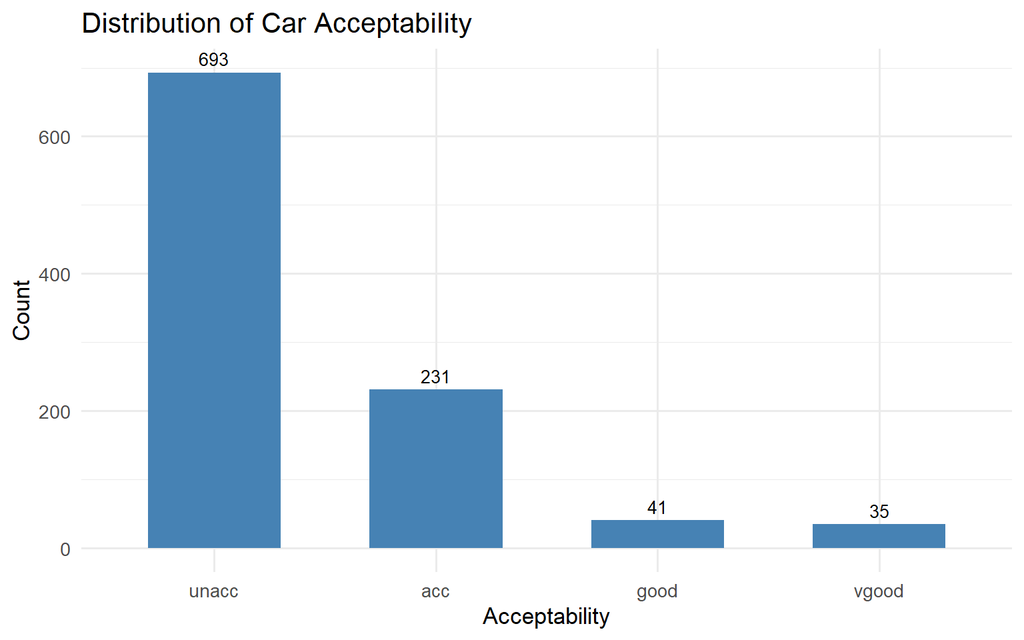

The dataset is heavily imbalanced — ‘unacc’ dominates.

```r
ggplot(df, aes(x = acceptability)) +
  geom_bar(fill = "steelblue", width = 0.6) +
  geom_text(stat = "count", aes(label = after_stat(count)), vjust = -0.5, size = 3.5) +
  labs(title = "Distribution of Car Acceptability",
       x = "Acceptability", y = "Count") +
  theme_minimal(base_size = 13)
```

> **Description:** The target variable is heavily imbalanced. The unacc class dominates while vgood is rarest. This imbalance has direct implications for evaluationoverall accuracy alone may be misleading, so per-class metrics such as sensitivity must also be considered (Lantz, 2019).

### 2.3.2 Buying price

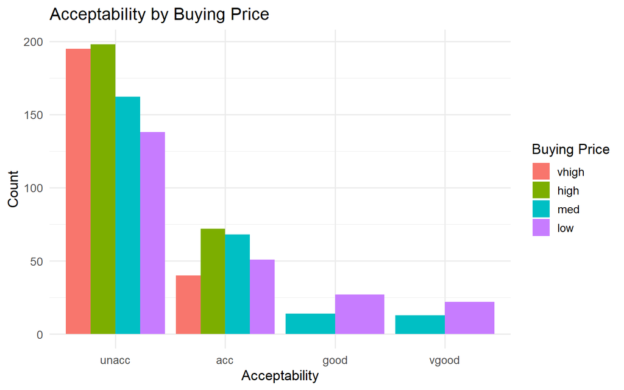

Very-high and high buying prices dominate the ‘unacc’ category.

```r
ggplot(df, aes(x = acceptability, fill = buying)) +
  geom_bar(position = "dodge") +
  labs(title = "Acceptability by Buying Price",
       x = "Acceptability", y = "Count", fill = "Buying Price") +
  theme_minimal(base_size = 13)
```

> **Description:** Very-high and high buying prices are concentrated in the `unacc` category, while lower prices (`low`, `med`) are spread more evenly across acceptability levels. This suggests that high cost is a barrier to acceptability but low cost alone does not guarantee a favourable rating.

### 2.3.3 Safety

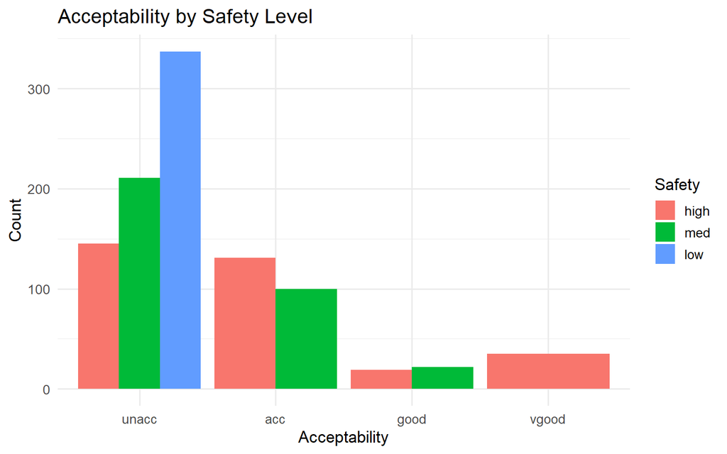

Low safety virtually guarantees unacceptability.

```r
ggplot(df, aes(x = acceptability, fill = safety)) +
  geom_bar(position = "dodge") +
  labs(title = "Acceptability by Safety Level",
       x = "Acceptability", y = "Count", fill = "Safety") +
  theme_minimal(base_size = 13)
```

> **Description:** Safety appears to be the strongest predictor of acceptability. Cars with low safety are never rated acc, good, or vgood, and vgood cars exclusively have high safety. This visual finding is later confirmed by both mutual information and chi-squared analysis an example of triangulation of evidence.

### 2.3.4 Persons

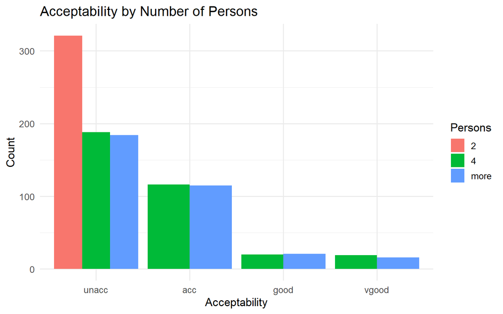

2-person cars are never rated above ‘unacc’.

```r
ggplot(df, aes(x = acceptability, fill = persons)) +
  geom_bar(position = "dodge") +
  labs(title = "Acceptability by Number of Persons",
       x = "Acceptability", y = "Count", fill = "Persons") +
  theme_minimal(base_size = 13)
```

> **Description:** Cars seating only 2 persons are exclusively rated `unacc`, making person capacity a hard constraint on acceptability. Cars with 4 or more seats are distributed across all classes, though `unacc` still dominates due to other factors.

### 2.3.5 Doors

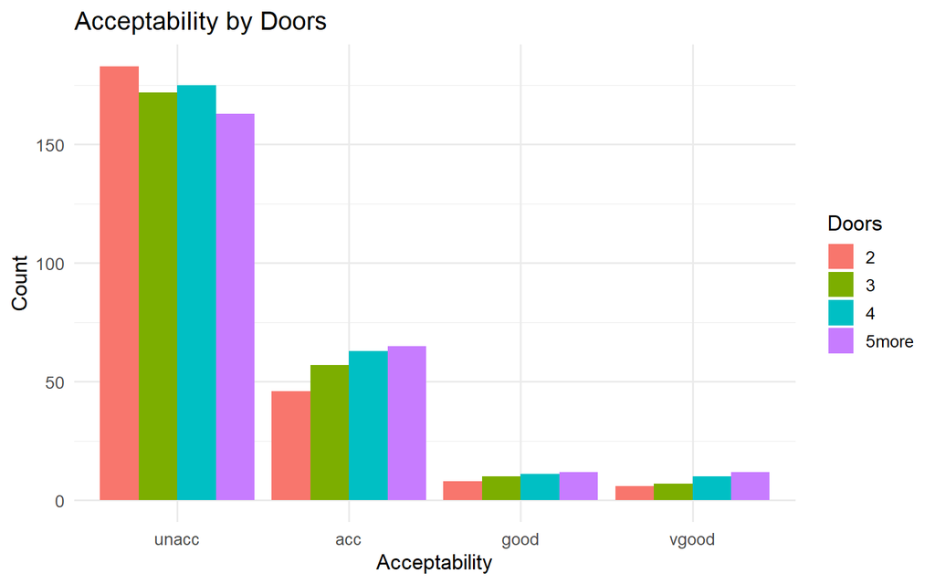

```r
ggplot(df, aes(x = acceptability, fill = doors)) +
  geom_bar(position = "dodge") +
  labs(title = "Acceptability by Doors",
       x = "Acceptability", y = "Count", fill = "Doors") +
  theme_minimal(base_size = 13)
```

> **Description:** The pattern mirrors 5more has more good and vgood acceptability.

# 3 Feature Relationships

## 3.1 Mutual Information Matrix

Mutual information (MI) measures the **strength** of a relationship between two variables. How much knowing one variable reduces uncertainty about the other.

> **Note:** The diagonal represents *entropy* (self-information), how uncertain we are about a variable on its own.

```r
m =mutinformation(df)
knitr::kable(round(m, 4), caption = "Mutual Information Matrix")
```

Mutual Information Matrix

|  | buying | maint | doors | persons | lug_boot | safety | acceptability |
| --- | --- | --- | --- | --- | --- | --- | --- |
| buying | 1.3847 | 0.0026 | 0.0026 | 0.0017 | 0.0013 | 0.0016 | 0.0675 |
| maint | 0.0026 | 1.3860 | 0.0024 | 0.0020 | 0.0006 | 0.0013 | 0.0591 |
| doors | 0.0026 | 0.0024 | 1.3860 | 0.0011 | 0.0016 | 0.0004 | 0.0040 |
| persons | 0.0017 | 0.0020 | 0.0011 | 1.0982 | 0.0015 | 0.0018 | 0.1493 |
| lug_boot | 0.0013 | 0.0006 | 0.0016 | 0.0015 | 1.0984 | 0.0002 | 0.0174 |
| safety | 0.0016 | 0.0013 | 0.0004 | 0.0018 | 0.0002 | 1.0986 | 0.1915 |
| acceptability | 0.0675 | 0.0591 | 0.0040 | 0.1493 | 0.0174 | 0.1915 | 0.8409 |

The values most relevant for modelling are the MI scores between each feature and the target (`acceptability`):

```r
mi_scores =m[7, -7]
mi_df =data.frame(
  Feature = names(mi_scores),
  MI      = as.numeric(mi_scores)
) |> arrange(desc(MI))

knitr::kable(mi_df, digits = 4, caption = "Mutual Information with Acceptability (ranked)")
```

Mutual Information with Acceptability (ranked)

| Feature | MI |
| --- | --- |
| safety | 0.1915 |
| persons | 0.1493 |
| buying | 0.0675 |
| maint | 0.0591 |
| lug_boot | 0.0174 |
| doors | 0.0040 |

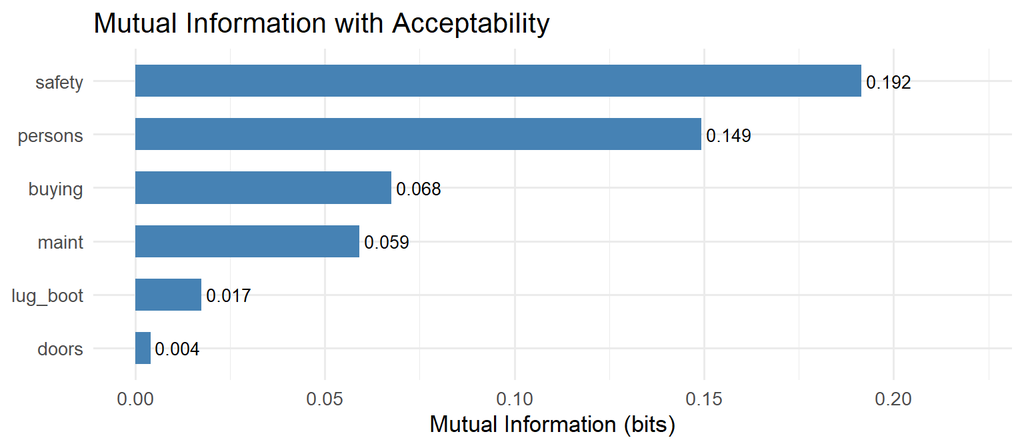

```r
ggplot(mi_df, aes(y = reorder(Feature, MI), x = MI)) +
  geom_col(fill = "steelblue", width = 0.6) +
  geom_text(aes(label = round(MI, 3)), hjust = -0.1, size = 3.5) +
  labs(title = "Mutual Information with Acceptability",
       y = NULL, x = "Mutual Information (bits)") +
  theme_minimal(base_size = 13) +
  xlim(0, max(mi_df$MI) * 1.15)
```

## 3.2 Chi-Squared Tests

The chi-squared test compares **observed counts** against **expected counts**. A large χ² statistic implies a genuine association.

| p-value | Interpretation |
| --- | --- |
| p > 0.05 | No significant relationship |
| p ≤ 0.05 | Statistically significant |
| p < 0.01 | Strong evidence of a relationship |
| p < 0.001 | Overwhelming evidence |

> **Analogy:** The null hypothesis (H₀: no relationship) is like a defendant presumed innocent. The prosecution must provide enough evidence (small p-value) to convict (reject H₀).

### 3.2.1 Buying vs. Acceptability

```r
chisq.test(df$buying, df$acceptability)
```

```
##
##  Pearson's Chi-squared test
##
## data:  df$buying and df$acceptability
## X-squared = 113.82, df = 9, p-value < 2.2e-16
```

With **p < 2.2e-16**, we have strong evidence that buying price and acceptability are related. Hence, we reject Null Hypothesis.

### 3.2.2 Buying vs. Maintenance

```r
chisq.test(df$buying, df$maint)
```

```
##
##  Pearson's Chi-squared test
##
## data:  df$buying and df$maint
## X-squared = 5.3384, df = 9, p-value = 0.8039
```

With **p < 0.8039**, It shows that buying and maintenance are not related. Hence, we accept Null Hypothesis.

### 3.2.3 lug_boot vs. Acceptability

```r
chisq.test(df$lug_boot, df$acceptability)
```

```
##
##  Pearson's Chi-squared test
##
## data:  df$lug_boot and df$acceptability
## X-squared = 24.334, df = 6, p-value = 0.0004533
```

### 3.2.4 Safety vs. Acceptability

```r
chisq.test(df$safety, df$acceptability)
```

```
##
##  Pearson's Chi-squared test
##
## data:  df$safety and df$acceptability
## X-squared = 294.47, df = 6, p-value < 2.2e-16
```

> Both mutual information and chi-squared agree that **safety is strongly tied to acceptability**. When two independent methods reach the same conclusion, confidence increases. This is known as *triangulation of evidence*.

# 4 Train / Test Split

Splitting the data before modelling is essential to get an honest estimate of how well a model will generalise to unseen data.

- **Overfitting** : the model memorises training data but fails on new data
- **Underfitting** : the model is too simple to capture any useful pattern

```r
set.seed(7463)
split    = sample.split(df$acceptability, SplitRatio = 0.8)
df_train = subset(df, split == TRUE)
df_test  = subset(df, split == FALSE)
```

## 4.1 Verifying the Split

```r
cat("Training rows:", nrow(df_train), "| Test rows:", nrow(df_test), "\n\n")
```

```
## Training rows: 800 | Test rows: 200
```

```r
split_check = rbind(
  Train = prop.table(table(df_train$acceptability)),
  Test  = prop.table(table(df_test$acceptability))
)
knitr::kable(round(split_check, 3), caption = "Class proportions — Train vs. Test")
```

Class proportions — Train vs. Test

|  | unacc | acc | good | vgood |
| --- | --- | --- | --- | --- |
| Train | 0.693 | 0.231 | 0.041 | 0.035 |
| Test | 0.695 | 0.230 | 0.040 | 0.035 |

The proportions are very similar between train and test, confirming a stratified split.

# 5 Machine Learning Algorithms

The analysis covers five classification algorithms:

| Algorithm | Intuition |
| --- | --- |
| **Decision Tree (C5.0)** | Splits data using a series of yes/no questions |
| **Naive Bayes** | Estimates class probabilities from feature likelihoods |
| **Logistic Regression** | Models class probabilities via a linear boundary |
| **SVM** | Finds the maximum-margin hyperplane between classes |
| **Neural Network** | Learns non-linear patterns through layered transforms |

## 5.1 The Universal ML Workflow

For every algorithm, the steps are identical:

```
1. TRAIN    - model       = algorithm(train_features, train_target)
2. PREDICT  - predictions = predict(model, test_data)
3. EVALUATE - confusionMatrix(predictions, true_labels)
4. RE-TRAIN - model
```

## 5.2 Decision Tree (C5.0)

Decision trees build a series of if/else rules by asking the question that most reduces uncertainty at each step (measured by *information gain*).

**Why C5.0?** It is the latest in the ID3 → C4.5 → C5.0 lineage, with better handling of categorical data and built-in pruning to reduce overfitting.

> **Analogy:** Is safety low? → Yes → predict `unacc`. No → Is persons = 2? → Yes → predict `unacc`. No → ask another question…

### 5.2.1 Training & Prediction

```r
set.seed(7463)
dt_model = C5.0(df_train[-7], df_train$acceptability)
dt_pred  = predict(dt_model, df_test)
```

### 5.2.2 Evaluation

A **confusion matrix** compares predictions against actual labels. Diagonal cells are correct predictions; off-diagonal cells are errors.

**Key metrics explained:**

| Metric | What it means |
| --- | --- |
| **Accuracy** | % of all predictions that were correct |
| **Kappa** | Accuracy adjusted for chance — values > 0.8 indicate excellent agreement |
| **Sensitivity** | Of all *actual* cars in a class, how many were correctly identified |
| **Specificity** | Of all cars *not* in a class, how many were correctly excluded |
| **Balanced Accuracy** | Average of Sensitivity & Specificity — useful for imbalanced classes |
| **Precision (PPV)** | When the model predicts a class, how often is it correct |
| **Detection Rate** | % of the entire test set correctly identified as that class |

```r
confusionMatrix(dt_pred, df_test$acceptability)
```

```
## Confusion Matrix and Statistics
##
##           Reference
## Prediction unacc acc good vgood
##      unacc   137   3    0     0
##      acc       1  43    0     2
##      good      1   0    8     0
##      vgood     0   0    0     5
##
## Overall Statistics
##
##                Accuracy : 0.965
##                  95% CI : (0.9292, 0.9858)
##     No Information Rate : 0.695
##     P-Value [Acc > NIR] : < 2.2e-16
##
##                   Kappa : 0.9236
##
##  Mcnemar's Test P-Value : NA
##
## Statistics by Class:
##
##                      Class: unacc Class: acc Class: good Class: vgood
## Sensitivity                0.9856     0.9348      1.0000       0.7143
## Specificity                0.9508     0.9805      0.9948       1.0000
## Pos Pred Value             0.9786     0.9348      0.8889       1.0000
## Neg Pred Value             0.9667     0.9805      1.0000       0.9897
## Prevalence                 0.6950     0.2300      0.0400       0.0350
## Detection Rate             0.6850     0.2150      0.0400       0.0250
## Detection Prevalence       0.7000     0.2300      0.0450       0.0250
## Balanced Accuracy          0.9682     0.9577      0.9974       0.8571
```

> **Insight:** The Decision Tree achieves 96.5% accuracy and a Kappa of 0.92. It correctly identifies all `good` cars (sensitivity = 1.0) but is weakest on `vgood` (sensitivity = 0.71), likely due to the small number of examples in that class.

## 5.3 Naive Bayes

Where decision trees ask *questions*, Naive Bayes calculates *probabilities*. It estimates the probability of each class given the features, then picks the most likely class.

> **Analogy:** You see something red, circular. Your brain combines past experience (“most red circular fruits are apples”) to conclude it’s an apple. Naive Bayes does exactly this using **Bayes’ Theorem**.

The “naive” assumption: all features are *independent* given the class rarely true, but often effective in practice.

```r
set.seed(7463)
nb_model = naiveBayes(df_train[, -7], df_train$acceptability)
nb_pred  =predict(nb_model, df_test)
confusionMatrix(nb_pred, df_test$acceptability)
```

```
## Confusion Matrix and Statistics
##
##           Reference
## Prediction unacc acc good vgood
##      unacc   131  11    3     0
##      acc       7  32    4     3
##      good      1   3    1     0
##      vgood     0   0    0     4
##
## Overall Statistics
##
##                Accuracy : 0.84
##                  95% CI : (0.7817, 0.8879)
##     No Information Rate : 0.695
##     P-Value [Acc > NIR] : 1.829e-06
##
##                   Kappa : 0.6376
##
##  Mcnemar's Test P-Value : NA
##
## Statistics by Class:
##
##                      Class: unacc Class: acc Class: good Class: vgood
## Sensitivity                0.9424     0.6957      0.1250       0.5714
## Specificity                0.7705     0.9091      0.9792       1.0000
## Pos Pred Value             0.9034     0.6957      0.2000       1.0000
## Neg Pred Value             0.8545     0.9091      0.9641       0.9847
## Prevalence                 0.6950     0.2300      0.0400       0.0350
## Detection Rate             0.6550     0.1600      0.0050       0.0200
## Detection Prevalence       0.7250     0.2300      0.0250       0.0200
## Balanced Accuracy          0.8565     0.8024      0.5521       0.7857
```

> **Insight:** Naive Bayes reaches 84% accuracy but struggles with the minority classes sensitivity for `good` is only 12.5%, meaning most `good` cars are misclassified. This reflects both the class imbalance and violations of the independence assumption.

## 5.4 Multinomial Logistic Regression

Multinomial logistic regression extends binary logistic regression to handle more than two classes. It fits one model per class against a reference, then converts the log-odds into class probabilities using the **softmax** function.

> **Analogy:** Each feature casts a weighted vote for each class. The class that accumulates the most evidence (highest probability) wins.

```r
set.seed(7463)
lg_model = multinom(acceptability ~ ., data = df_train, trace = FALSE)
lg_pred  =predict(lg_model, df_test)
confusionMatrix(lg_pred, df_test$acceptability)
```

```
## Confusion Matrix and Statistics
##
##           Reference
## Prediction unacc acc good vgood
##      unacc   132   3    0     0
##      acc       6  41    1     1
##      good      1   2    7     0
##      vgood     0   0    0     6
##
## Overall Statistics
##
##                Accuracy : 0.93
##                  95% CI : (0.8853, 0.9612)
##     No Information Rate : 0.695
##     P-Value [Acc > NIR] : 3.476e-16
##
##                   Kappa : 0.8515
##
##  Mcnemar's Test P-Value : NA
##
## Statistics by Class:
##
##                      Class: unacc Class: acc Class: good Class: vgood
## Sensitivity                0.9496     0.8913      0.8750       0.8571
## Specificity                0.9508     0.9481      0.9844       1.0000
## Pos Pred Value             0.9778     0.8367      0.7000       1.0000
## Neg Pred Value             0.8923     0.9669      0.9947       0.9948
## Prevalence                 0.6950     0.2300      0.0400       0.0350
## Detection Rate             0.6600     0.2050      0.0350       0.0300
## Detection Prevalence       0.6750     0.2450      0.0500       0.0300
## Balanced Accuracy          0.9502     0.9197      0.9297       0.9286
```

> **Insight:** Logistic Regression achieves 93% accuracy with more balanced per-class sensitivity than Naive Bayes (e.g. 87.5% for `good` and 85.7% for `vgood`), indicating it handles minority classes more effectively.

## 5.5 Support Vector Machine (SVM)

SVMs find the **maximum-margin hyperplane** that best separates classes. Using the **radial basis function (RBF) kernel**, SVMs can model non-linear decision boundaries by implicitly mapping data into a higher-dimensional space.

> **Analogy:** Imagine drawing a road between two groups of points. SVM finds the widest possible road. The points touching, the road edges are the “support vectors”.

```r
set.seed(7463)
svm_model = ksvm(acceptability ~ ., data = df_train, kernel = "rbfdot")
svm_pred  =predict(svm_model, df_test)
confusionMatrix(svm_pred, df_test$acceptability)
```

```
## Confusion Matrix and Statistics
##
##           Reference
## Prediction unacc acc good vgood
##      unacc   132   0    0     0
##      acc       7  46    8     2
##      good      0   0    0     0
##      vgood     0   0    0     5
##
## Overall Statistics
##
##                Accuracy : 0.915
##                  95% CI : (0.8674, 0.9497)
##     No Information Rate : 0.695
##     P-Value [Acc > NIR] : 4.783e-14
##
##                   Kappa : 0.8184
##
##  Mcnemar's Test P-Value : NA
##
## Statistics by Class:
##
##                      Class: unacc Class: acc Class: good Class: vgood
## Sensitivity                0.9496     1.0000        0.00       0.7143
## Specificity                1.0000     0.8896        1.00       1.0000
## Pos Pred Value             1.0000     0.7302         NaN       1.0000
## Neg Pred Value             0.8971     1.0000        0.96       0.9897
## Prevalence                 0.6950     0.2300        0.04       0.0350
## Detection Rate             0.6600     0.2300        0.00       0.0250
## Detection Prevalence       0.6600     0.3150        0.00       0.0250
## Balanced Accuracy          0.9748     0.9448        0.50       0.8571
```

## 5.6 Neural Network

Neural networks learn patterns through layered transformations. An **input layer** receives the features, one or more **hidden layers** apply non-linear activations, and an **output layer** produces class probabilities via softmax.

> **Analogy:** Just as biological neurons fire when sufficiently stimulated, artificial neurons activate when a weighted sum of inputs exceeds a threshold, cascading through layers to produce a prediction.

```r
set.seed(7463)
nn_model = nnet(acceptability ~., data = df_train, size = 5, trace = FALSE)
nn_pred = predict(nn_model, df_test, type = "class")
confusionMatrix(factor(nn_pred), df_test$acceptability)
```

```
## Confusion Matrix and Statistics
##
##           Reference
## Prediction unacc acc good vgood
##      unacc   135   0    0     0
##      acc       3  45    1     1
##      good      1   1    7     0
##      vgood     0   0    0     6
##
## Overall Statistics
##
##                Accuracy : 0.965
##                  95% CI : (0.9292, 0.9858)
##     No Information Rate : 0.695
##     P-Value [Acc > NIR] : < 2.2e-16
##
##                   Kappa : 0.9256
##
##  Mcnemar's Test P-Value : NA
##
## Statistics by Class:
##
##                      Class: unacc Class: acc Class: good Class: vgood
## Sensitivity                0.9712     0.9783      0.8750       0.8571
## Specificity                1.0000     0.9675      0.9896       1.0000
## Pos Pred Value             1.0000     0.9000      0.7778       1.0000
## Neg Pred Value             0.9385     0.9933      0.9948       0.9948
## Prevalence                 0.6950     0.2300      0.0400       0.0350
## Detection Rate             0.6750     0.2250      0.0350       0.0300
## Detection Prevalence       0.6750     0.2500      0.0450       0.0300
## Balanced Accuracy          0.9856     0.9729      0.9323       0.9286
```

> **Insight:** The Neural Network matches the Decision Tree at 96.5% accuracy and delivers the most balanced sensitivity across all four classes (≥ 85.7%), making it the strongest overall baseline model when per-class performance is considered.

# 6 Model Comparison

## 6.1 Baseline Accuracy Summary

```r
results = data.frame(
  Model = c("Decision Tree (C5.0)", "Naive Bayes",
            "Logistic Regression", "SVM (RBF)", "Neural Network"),
  Accuracy = c(
    confusionMatrix(dt_pred,  df_test$acceptability)$overall["Accuracy"],
    confusionMatrix(nb_pred,  df_test$acceptability)$overall["Accuracy"],
    confusionMatrix(lg_pred,  df_test$acceptability)$overall["Accuracy"],
    confusionMatrix(svm_pred, df_test$acceptability)$overall["Accuracy"],
    confusionMatrix(
      factor(nn_pred, levels = levels(df_test$acceptability)),
      df_test$acceptability
    )$overall["Accuracy"]
  )
)

results$Accuracy =round(results$Accuracy * 100, 2)
results =results[order(-results$Accuracy), ]

knitr::kable(results, row.names = FALSE,
             caption = "Test Set Accuracy — Baseline Models")
```

Test Set Accuracy — Baseline Models

| Model | Accuracy |
| --- | --- |
| Decision Tree (C5.0) | 96.5 |
| Neural Network | 96.5 |
| Logistic Regression | 93.0 |
| SVM (RBF) | 91.5 |
| Naive Bayes | 84.0 |

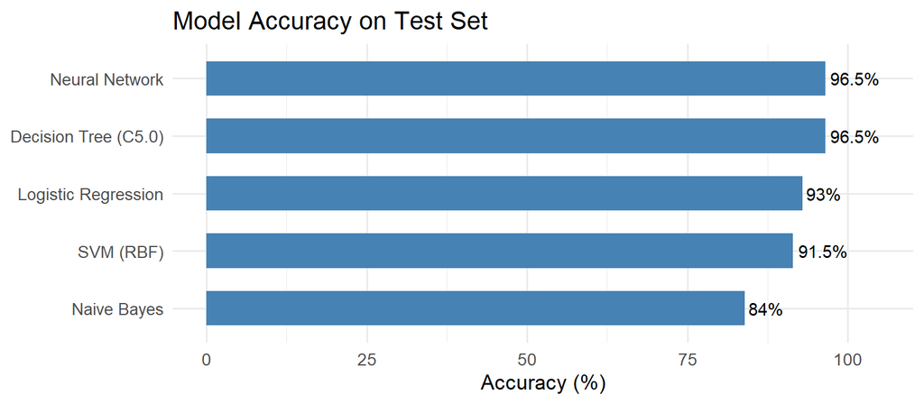

Baseline model accuracy on the held-out test set.

```r
ggplot(results, aes(y = reorder(Model, Accuracy), x = Accuracy)) +
  geom_col(fill = "steelblue", width = 0.6) +
  geom_text(aes(label = paste0(Accuracy, "%")), hjust = -0.1, size = 3.8) +
  labs(title = "Model Accuracy on Test Set",
       y = NULL, x = "Accuracy (%)") +
  theme_minimal(base_size = 13) +
  xlim(0, 105)
```

# 7 10-Fold Cross-Validation

Evaluating a model on a single train/test split can be sensitive to the particular random partition. **K-fold cross-validation** mitigates this by:

1. Dividing the data into *k* equal folds
2. Training on *k − 1* folds, testing on the remaining fold
3. Repeating *k* times and averaging the results

This provides a more robust and unbiased performance estimate. All cross-validation and tuning workflows in this report use the `caret` framework (Kuhn, 2008).

```r
ctrl = trainControl(method = "cv", number = 10)
```

## 7.1 Decision Tree with CV

```r
set.seed(7463)
dt_cv_model = train(df_train[-7], df_train$acceptability,
                     method = "C5.0", trControl = ctrl)
dt_cv_pred  = predict(dt_cv_model, df_test)
confusionMatrix(dt_cv_pred, df_test$acceptability)
```

```
## Confusion Matrix and Statistics
##
##           Reference
## Prediction unacc acc good vgood
##      unacc   138   1    1     0
##      acc       1  44    0     0
##      good      0   1    7     0
##      vgood     0   0    0     7
##
## Overall Statistics
##
##                Accuracy : 0.98
##                  95% CI : (0.9496, 0.9945)
##     No Information Rate : 0.695
##     P-Value [Acc > NIR] : < 2.2e-16
##
##                   Kappa : 0.9564
##
##  Mcnemar's Test P-Value : NA
##
## Statistics by Class:
##
##                      Class: unacc Class: acc Class: good Class: vgood
## Sensitivity                0.9928     0.9565      0.8750        1.000
## Specificity                0.9672     0.9935      0.9948        1.000
## Pos Pred Value             0.9857     0.9778      0.8750        1.000
## Neg Pred Value             0.9833     0.9871      0.9948        1.000
## Prevalence                 0.6950     0.2300      0.0400        0.035
## Detection Rate             0.6900     0.2200      0.0350        0.035
## Detection Prevalence       0.7000     0.2250      0.0400        0.035
## Balanced Accuracy          0.9800     0.9750      0.9349        1.000
```

## 7.2 Naive Bayes with CV

```r
set.seed(7463)
nb_cv_model = train(df_train[-7], df_train$acceptability,
                     method = "nb", trControl = ctrl)
nb_cv_pred  = predict(nb_cv_model, df_test)
confusionMatrix(nb_cv_pred, df_test$acceptability)
```

```
## Confusion Matrix and Statistics
##
##           Reference
## Prediction unacc acc good vgood
##      unacc   131  11    3     0
##      acc       7  32    4     3
##      good      1   3    1     0
##      vgood     0   0    0     4
##
## Overall Statistics
##
##                Accuracy : 0.84
##                  95% CI : (0.7817, 0.8879)
##     No Information Rate : 0.695
##     P-Value [Acc > NIR] : 1.829e-06
##
##                   Kappa : 0.6376
##
##  Mcnemar's Test P-Value : NA
##
## Statistics by Class:
##
##                      Class: unacc Class: acc Class: good Class: vgood
## Sensitivity                0.9424     0.6957      0.1250       0.5714
## Specificity                0.7705     0.9091      0.9792       1.0000
## Pos Pred Value             0.9034     0.6957      0.2000       1.0000
## Neg Pred Value             0.8545     0.9091      0.9641       0.9847
## Prevalence                 0.6950     0.2300      0.0400       0.0350
## Detection Rate             0.6550     0.1600      0.0050       0.0200
## Detection Prevalence       0.7250     0.2300      0.0250       0.0200
## Balanced Accuracy          0.8565     0.8024      0.5521       0.7857
```

> **Insight:** Naive Bayes accuracy remains at 84.0%, unchanged from the baseline, indicating its limitations are structural rather than a product of the particular train/test split.

## 7.3 Logistic Regression with CV

```r
set.seed(7463)
lg_cv_model = train(df_train[, -7], df_train$acceptability,
                     method = "multinom", trControl = ctrl, trace = FALSE)
lg_cv_pred  = predict(lg_cv_model, df_test)
confusionMatrix(lg_cv_pred, df_test$acceptability)
```

```
## Confusion Matrix and Statistics
##
##           Reference
## Prediction unacc acc good vgood
##      unacc   131   3    0     0
##      acc       6  41    1     1
##      good      1   2    7     0
##      vgood     1   0    0     6
##
## Overall Statistics
##
##                Accuracy : 0.925
##                  95% CI : (0.8793, 0.9574)
##     No Information Rate : 0.695
##     P-Value [Acc > NIR] : 1.921e-15
##
##                   Kappa : 0.842
##
##  Mcnemar's Test P-Value : NA
##
## Statistics by Class:
##
##                      Class: unacc Class: acc Class: good Class: vgood
## Sensitivity                0.9424     0.8913      0.8750       0.8571
## Specificity                0.9508     0.9481      0.9844       0.9948
## Pos Pred Value             0.9776     0.8367      0.7000       0.8571
## Neg Pred Value             0.8788     0.9669      0.9947       0.9948
## Prevalence                 0.6950     0.2300      0.0400       0.0350
## Detection Rate             0.6550     0.2050      0.0350       0.0300
## Detection Prevalence       0.6700     0.2450      0.0500       0.0350
## Balanced Accuracy          0.9466     0.9197      0.9297       0.9260
```

> **Insight:** Logistic Regression holds steady at 92.5%, closely matching its baseline of 93.0%.

## 7.4 Neural Network with CV

```r
set.seed(7463)
nn_cv_model = train(df_train[, -7], df_train$acceptability,
                     method = "nnet", trControl = ctrl, trace = FALSE)
nn_cv_pred  = predict(nn_cv_model, df_test)
confusionMatrix(nn_cv_pred, df_test$acceptability)
```

```
## Confusion Matrix and Statistics
##
##           Reference
## Prediction unacc acc good vgood
##      unacc   137   0    0     0
##      acc       1  45    1     1
##      good      1   1    7     0
##      vgood     0   0    0     6
##
## Overall Statistics
##
##                Accuracy : 0.975
##                  95% CI : (0.9426, 0.9918)
##     No Information Rate : 0.695
##     P-Value [Acc > NIR] : < 2.2e-16
##
##                   Kappa : 0.9463
##
##  Mcnemar's Test P-Value : NA
##
## Statistics by Class:
##
##                      Class: unacc Class: acc Class: good Class: vgood
## Sensitivity                0.9856     0.9783      0.8750       0.8571
## Specificity                1.0000     0.9805      0.9896       1.0000
## Pos Pred Value             1.0000     0.9375      0.7778       1.0000
## Neg Pred Value             0.9683     0.9934      0.9948       0.9948
## Prevalence                 0.6950     0.2300      0.0400       0.0350
## Detection Rate             0.6850     0.2250      0.0350       0.0300
## Detection Prevalence       0.6850     0.2400      0.0450       0.0300
## Balanced Accuracy          0.9928     0.9794      0.9323       0.9286
```

## 7.5 SVM with CV

```r
set.seed(7463)
svm_cv_model = ksvm(acceptability ~ ., data = df_train,
                     kernel = "vanilladot", cross = 10)
svm_cv_pred  = predict(svm_cv_model, df_test)
confusionMatrix(svm_cv_pred, df_test$acceptability)
```

```
## Confusion Matrix and Statistics
##
##           Reference
## Prediction unacc acc good vgood
##      unacc   134   4    0     0
##      acc       4  41    5     2
##      good      1   1    3     0
##      vgood     0   0    0     5
##
## Overall Statistics
##
##                Accuracy : 0.915
##                  95% CI : (0.8674, 0.9497)
##     No Information Rate : 0.695
##     P-Value [Acc > NIR] : 4.783e-14
##
##                   Kappa : 0.8147
##
##  Mcnemar's Test P-Value : NA
##
## Statistics by Class:
##
##                      Class: unacc Class: acc Class: good Class: vgood
## Sensitivity                0.9640     0.8913      0.3750       0.7143
## Specificity                0.9344     0.9286      0.9896       1.0000
## Pos Pred Value             0.9710     0.7885      0.6000       1.0000
## Neg Pred Value             0.9194     0.9662      0.9744       0.9897
## Prevalence                 0.6950     0.2300      0.0400       0.0350
## Detection Rate             0.6700     0.2050      0.0150       0.0250
## Detection Prevalence       0.6900     0.2600      0.0250       0.0250
## Balanced Accuracy          0.9492     0.9099      0.6823       0.8571
```

## 7.6 Cross-Validation Summary

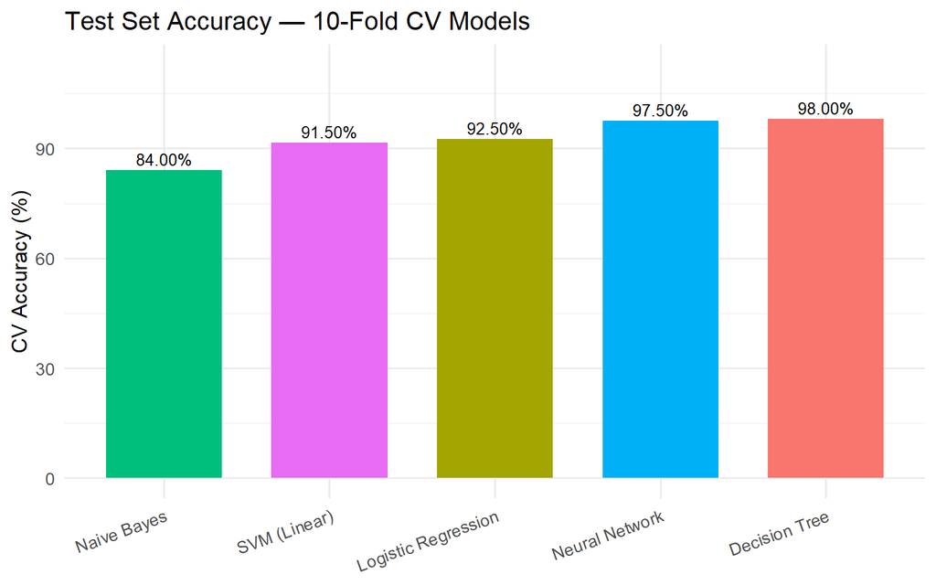

```r
cv_results = data.frame(
  Model = c("Decision Tree", "Naive Bayes", "Logistic Regression",
            "Neural Network", "SVM (Linear)"),
  CV_Accuracy = round(c(
    confusionMatrix(dt_cv_pred, df_test$acceptability)$overall["Accuracy"],
    confusionMatrix(nb_cv_pred, df_test$acceptability)$overall["Accuracy"],
    confusionMatrix(lg_cv_pred, df_test$acceptability)$overall["Accuracy"],
    confusionMatrix(nn_cv_pred, df_test$acceptability)$overall["Accuracy"],
    confusionMatrix(svm_cv_pred, df_test$acceptability)$overall["Accuracy"]
  ) * 100, 2)
)

ggplot(cv_results, aes(x = reorder(Model, CV_Accuracy), y = CV_Accuracy, fill = Model)) +
  geom_col(width = 0.7) +
  geom_text(aes(label = sprintf("%.2f%%", CV_Accuracy)),
            vjust = -0.4, size = 3.5) +
  labs(title = "Test Set Accuracy — 10-Fold CV Models",
       x = NULL, y = "CV Accuracy (%)") +
  theme_minimal(base_size = 13) +
  theme(legend.position = "none",
        axis.text.x = element_text(angle = 20, hjust = 1)) +
  ylim(0, max(cv_results$CV_Accuracy) * 1.15)
```

# 8 Filter-Based Feature Selection

Not all features contribute equally to classification.So, Its better to drop the weak features, keep only the strong ones, retrain models, see if performance holds up or not. Why bother dropping features?, Because it makes model to train fast, less overfitting and simpler model. > **Analogy:** Imagine you are going for the shopping and you have not made a list. Then you sniff around whole mart and thinking what should i buy. If you made a list for item what you needed than it could save your time and money as well. Same goes to Feature Selection.

## 8.1 Step 1 : Recompute MI on the training set only

> **Important:** Feature selection must only inspect the **training data**. Looking at the test data here would leak information and inflate test accuracy artificially.

```r
set.seed(7463)
m_train = mutinformation(df_train)
round(m_train[7, -7], 4)
```

```
##   buying    maint    doors  persons lug_boot   safety
##   0.0689   0.0616   0.0032   0.1525   0.0165   0.1888
```

## 8.2 Step 2 : Build feature-selected datasets

We select columns by **name** (not index). cleaner and less error-prone.

```r
set.seed(7463)
top_features = c("safety", "persons", "lug_boot")
df_train_fs  = df_train[, c(top_features, "acceptability")]
df_test_fs   = df_test[,  c(top_features, "acceptability")]

str(df_train_fs)
```

```
## 'data.frame':    800 obs. of  4 variables:
##  $ safety       : Factor w/ 4 levels "vhigh","high",..: 4 4 3 4 2 3 3 3 2 2 ...
##  $ persons      : Factor w/ 3 levels "2","4","more": 2 1 2 2 1 1 2 3 2 3 ...
##  $ lug_boot     : Factor w/ 3 levels "big","med","small": 3 2 1 2 2 1 3 1 3 3 ...
##  $ acceptability: Factor w/ 4 levels "unacc","acc",..: 1 1 1 1 1 1 2 3 2 2 ...
```

## 8.3 Step 3 : What to look for

The accuracy may rise, fall, or stay the same:

- **Tiny drop or no change** : the dropped features were mostly noise (good outcome).
- **Large drop** : useful information was discarded.
- **Improvement** : the model was being confused by noisy features.

For Naive Bayes specifically, removing features often **improves** performance because fewer pairs of features can violate its independence assumption.

### 8.3.1 Decision Tree Selected Features

```r
set.seed(7463)
dt_fs_model = C5.0(df_train_fs[, -4], df_train_fs$acceptability)
dt_fs_pred  = predict(dt_fs_model, df_test_fs)
confusionMatrix(dt_fs_pred, df_test_fs$acceptability)
```

```
## Confusion Matrix and Statistics
##
##           Reference
## Prediction unacc acc good vgood
##      unacc   117   4    0     0
##      acc      22  42    8     7
##      good      0   0    0     0
##      vgood     0   0    0     0
##
## Overall Statistics
##
##                Accuracy : 0.795
##                  95% CI : (0.7323, 0.8487)
##     No Information Rate : 0.695
##     P-Value [Acc > NIR] : 0.0009873
##
##                   Kappa : 0.5805
##
##  Mcnemar's Test P-Value : NA
##
## Statistics by Class:
##
##                      Class: unacc Class: acc Class: good Class: vgood
## Sensitivity                0.8417     0.9130        0.00        0.000
## Specificity                0.9344     0.7597        1.00        1.000
## Pos Pred Value             0.9669     0.5316         NaN          NaN
## Neg Pred Value             0.7215     0.9669        0.96        0.965
## Prevalence                 0.6950     0.2300        0.04        0.035
## Detection Rate             0.5850     0.2100        0.00        0.000
## Detection Prevalence       0.6050     0.3950        0.00        0.000
## Balanced Accuracy          0.8881     0.8364        0.50        0.500
```

### 8.3.2 Naive Bayes Selected Features

```r
set.seed(7463)
nb_fs_model = naiveBayes(df_train_fs[, -4], df_train_fs$acceptability)
nb_fs_pred  =predict(nb_fs_model, df_test_fs)
confusionMatrix(nb_fs_pred, df_test_fs$acceptability)
```

```
## Confusion Matrix and Statistics
##
##           Reference
## Prediction unacc acc good vgood
##      unacc   125  16    5     0
##      acc      14  30    3     7
##      good      0   0    0     0
##      vgood     0   0    0     0
##
## Overall Statistics
##
##                Accuracy : 0.775
##                  95% CI : (0.7108, 0.8309)
##     No Information Rate : 0.695
##     P-Value [Acc > NIR] : 0.007424
##
##                   Kappa : 0.4774
##
##  Mcnemar's Test P-Value : NA
##
## Statistics by Class:
##
##                      Class: unacc Class: acc Class: good Class: vgood
## Sensitivity                0.8993     0.6522        0.00        0.000
## Specificity                0.6557     0.8442        1.00        1.000
## Pos Pred Value             0.8562     0.5556         NaN          NaN
## Neg Pred Value             0.7407     0.8904        0.96        0.965
## Prevalence                 0.6950     0.2300        0.04        0.035
## Detection Rate             0.6250     0.1500        0.00        0.000
## Detection Prevalence       0.7300     0.2700        0.00        0.000
## Balanced Accuracy          0.7775     0.7482        0.50        0.500
```

### 8.3.3 Logistic Regression Selected Features

```r
set.seed(7463)
lg_fs_model =multinom(acceptability ~ safety + persons + buying,
                        data = df_train, trace = FALSE)
lg_fs_pred  =predict(lg_fs_model, df_test)
confusionMatrix(lg_fs_pred, df_test$acceptability)
```

```
## Confusion Matrix and Statistics
##
##           Reference
## Prediction unacc acc good vgood
##      unacc   120   6    0     0
##      acc      17  34    6     1
##      good      0   0    0     0
##      vgood     2   6    2     6
##
## Overall Statistics
##
##                Accuracy : 0.8
##                  95% CI : (0.7378, 0.8531)
##     No Information Rate : 0.695
##     P-Value [Acc > NIR] : 0.0005557
##
##                   Kappa : 0.594
##
##  Mcnemar's Test P-Value : NA
##
## Statistics by Class:
##
##                      Class: unacc Class: acc Class: good Class: vgood
## Sensitivity                0.8633     0.7391        0.00       0.8571
## Specificity                0.9016     0.8442        1.00       0.9482
## Pos Pred Value             0.9524     0.5862         NaN       0.3750
## Neg Pred Value             0.7432     0.9155        0.96       0.9946
## Prevalence                 0.6950     0.2300        0.04       0.0350
## Detection Rate             0.6000     0.1700        0.00       0.0300
## Detection Prevalence       0.6300     0.2900        0.00       0.0800
## Balanced Accuracy          0.8825     0.7916        0.50       0.9027
```

### 8.3.4 SVM Selected Features

```r
set.seed(7463)
svm_fs_model =ksvm(acceptability ~ safety + persons + buying,
                     data = df_train, kernel = "vanilladot")
svm_fs_pred  =predict(svm_fs_model, df_test)
confusionMatrix(svm_fs_pred, df_test$acceptability)
```

```
## Confusion Matrix and Statistics
##
##           Reference
## Prediction unacc acc good vgood
##      unacc   120   6    0     0
##      acc      17  34    6     1
##      good      0   0    0     0
##      vgood     2   6    2     6
##
## Overall Statistics
##
##                Accuracy : 0.8
##                  95% CI : (0.7378, 0.8531)
##     No Information Rate : 0.695
##     P-Value [Acc > NIR] : 0.0005557
##
##                   Kappa : 0.594
##
##  Mcnemar's Test P-Value : NA
##
## Statistics by Class:
##
##                      Class: unacc Class: acc Class: good Class: vgood
## Sensitivity                0.8633     0.7391        0.00       0.8571
## Specificity                0.9016     0.8442        1.00       0.9482
## Pos Pred Value             0.9524     0.5862         NaN       0.3750
## Neg Pred Value             0.7432     0.9155        0.96       0.9946
## Prevalence                 0.6950     0.2300        0.04       0.0350
## Detection Rate             0.6000     0.1700        0.00       0.0300
## Detection Prevalence       0.6300     0.2900        0.00       0.0800
## Balanced Accuracy          0.8825     0.7916        0.50       0.9027
```

### 8.3.5 Neural Network Selected Features

```r
set.seed(7463)
nn_fs_model =nnet(acceptability ~ persons + buying + safety,
                    data = df_train, size = 5, trace = FALSE)
nn_fs_pred  =predict(nn_fs_model, df_test, type = "class")
confusionMatrix(factor(nn_fs_pred, levels = levels(df_test$acceptability)),
                df_test$acceptability)
```

```
## Confusion Matrix and Statistics
##
##           Reference
## Prediction unacc acc good vgood
##      unacc   123   8    0     0
##      acc      15  30    7     2
##      good      1   3    0     0
##      vgood     0   5    1     5
##
## Overall Statistics
##
##                Accuracy : 0.79
##                  95% CI : (0.7269, 0.8443)
##     No Information Rate : 0.695
##     P-Value [Acc > NIR] : 0.001704
##
##                   Kappa : 0.5625
##
##  Mcnemar's Test P-Value : NA
##
## Statistics by Class:
##
##                      Class: unacc Class: acc Class: good Class: vgood
## Sensitivity                0.8849     0.6522      0.0000       0.7143
## Specificity                0.8689     0.8442      0.9792       0.9689
## Pos Pred Value             0.9389     0.5556      0.0000       0.4545
## Neg Pred Value             0.7681     0.8904      0.9592       0.9894
## Prevalence                 0.6950     0.2300      0.0400       0.0350
## Detection Rate             0.6150     0.1500      0.0000       0.0250
## Detection Prevalence       0.6550     0.2700      0.0200       0.0550
## Balanced Accuracy          0.8769     0.7482      0.4896       0.8416
```

> **Insight:** The Neural Network suffers the largest absolute drop (96.5% → 79.0%), consistent with neural networks benefiting from richer input to capture feature interactions.

## 8.4 Bonus — Top 4 features

A useful sanity check: keep the top 4 features (add `maint`) and re-run the Decision Tree. If accuracy with 4 features ≈ accuracy with all 6, then `lug_boot` and `doors` are confirmed as truly redundant.

```r
set.seed(7463)
top_features_4 =c("safety", "persons", "buying", "maint")
df_train_fs4   =df_train[, c(top_features_4, "acceptability")]
df_test_fs4    =df_test[,  c(top_features_4, "acceptability")]

dt_fs4_model =C5.0(df_train_fs4[, -5], df_train_fs4$acceptability)
dt_fs4_pred  =predict(dt_fs4_model, df_test_fs4)
confusionMatrix(dt_fs4_pred, df_test_fs4$acceptability)
```

```
## Confusion Matrix and Statistics
##
##           Reference
## Prediction unacc acc good vgood
##      unacc   133   5    0     0
##      acc       5  38    5     2
##      good      0   1    0     0
##      vgood     1   2    3     5
##
## Overall Statistics
##
##                Accuracy : 0.88
##                  95% CI : (0.8267, 0.9216)
##     No Information Rate : 0.695
##     P-Value [Acc > NIR] : 5.983e-10
##
##                   Kappa : 0.7396
##
##  Mcnemar's Test P-Value : NA
##
## Statistics by Class:
##
##                      Class: unacc Class: acc Class: good Class: vgood
## Sensitivity                0.9568     0.8261      0.0000       0.7143
## Specificity                0.9180     0.9221      0.9948       0.9689
## Pos Pred Value             0.9638     0.7600      0.0000       0.4545
## Neg Pred Value             0.9032     0.9467      0.9598       0.9894
## Prevalence                 0.6950     0.2300      0.0400       0.0350
## Detection Rate             0.6650     0.1900      0.0000       0.0250
## Detection Prevalence       0.6900     0.2500      0.0050       0.0550
## Balanced Accuracy          0.9374     0.8741      0.4974       0.8416
```

### 8.4.1 Feature Selection Summary

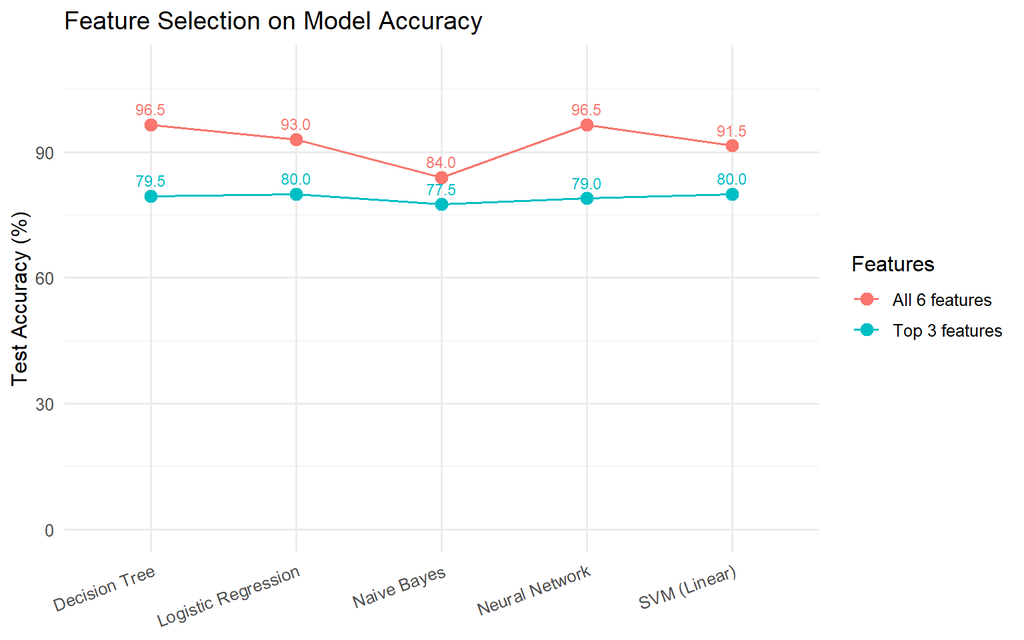

```r
fs_results = data.frame(
  Model = c("Decision Tree", "Naive Bayes", "Logistic Regression",
            "SVM (Linear)", "Neural Network"),
  All_Features = round(c(
    confusionMatrix(dt_pred, df_test$acceptability)$overall["Accuracy"],
    confusionMatrix(nb_pred, df_test$acceptability)$overall["Accuracy"],
    confusionMatrix(lg_pred, df_test$acceptability)$overall["Accuracy"],
    confusionMatrix(svm_pred, df_test$acceptability)$overall["Accuracy"],
    confusionMatrix(factor(nn_pred, levels = levels(df_test$acceptability)),
                    df_test$acceptability)$overall["Accuracy"]
  ) * 100, 2),
  Selected_Features = round(c(
    confusionMatrix(dt_fs_pred, df_test_fs$acceptability)$overall["Accuracy"],
    confusionMatrix(nb_fs_pred, df_test_fs$acceptability)$overall["Accuracy"],
    confusionMatrix(lg_fs_pred, df_test$acceptability)$overall["Accuracy"],
    confusionMatrix(svm_fs_pred, df_test$acceptability)$overall["Accuracy"],
    confusionMatrix(factor(nn_fs_pred, levels = levels(df_test$acceptability)),
                    df_test$acceptability)$overall["Accuracy"]
  ) * 100, 2)
)

fs_results$Delta = fs_results$Selected_Features - fs_results$All_Features

fs_long =data.frame(
  Model    = rep(fs_results$Model, 2),
  Features = c(rep("All 6 features", nrow(fs_results)),
               rep("Top 3 features", nrow(fs_results))),
  Accuracy = c(fs_results$All_Features, fs_results$Selected_Features)
)

ggplot(fs_long, aes(x = Model, y = Accuracy, color = Features, group = Features)) +
  geom_point(size = 3) +
  geom_line() +
  geom_text(aes(label = sprintf("%.1f", Accuracy)),
            vjust = -0.8, size = 3, show.legend = FALSE) +
  labs(title = "Feature Selection on Model Accuracy",
       x = NULL, y = "Test Accuracy (%)", color = "Features") +
  theme_minimal(base_size = 12) +
  theme(axis.text.x = element_text(angle = 20, hjust = 1)) +
  ylim(0, 110)
```

# 9 Improving Model Performance — Hyperparameter Tuning

When a model memorises the training data but fails to generalise, it is **overfitting**. When it is too simple to capture useful patterns, it is **underfitting**. Hyperparameter tuning searches for the configuration that balances both.

We use **repeated 10-fold CV** (10 repeats) for robust tuning.

```r
ctrl_tune =trainControl(method = "repeatedcv", number = 10, repeats = 10)
```

## 9.1 Neural Network Tuning

We tune the `decay` parameter (weight regularisation) while fixing the hidden layer size to 5.

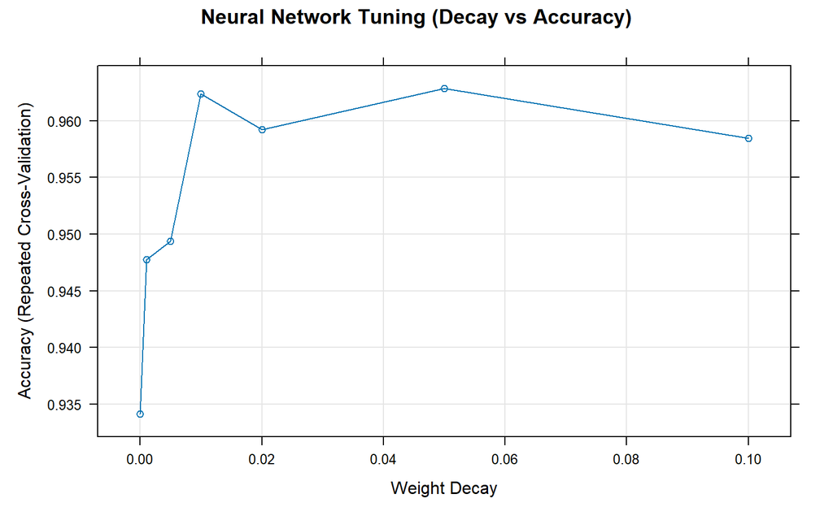

Neural Network — accuracy across decay values.

```r
set.seed(7463)
grid_nn =expand.grid(size = 5,
                       decay = c(0, 0.001, 0.005, 0.01, 0.02, 0.05, 0.1))

set.seed(7463)
nn_tuned =train(df_train[-7], df_train$acceptability,
                  method = "nnet", trControl = ctrl_tune,
                  tuneGrid = grid_nn, trace = FALSE)

plot(nn_tuned, main = "Neural Network Tuning (Decay vs Accuracy)")
```

> **Description:** Decay acts as regularisation. Too low (≈ 0) risks overfitting; too high prevents the network from learning. The optimum is `decay = 0.05, which balances flexibility against generalisation (Kuhn, 2008).

## 9.2 Decision Tree Tuning

We search across different numbers of boosting **trials**, a additional passes that focus on previously misclassified examples.

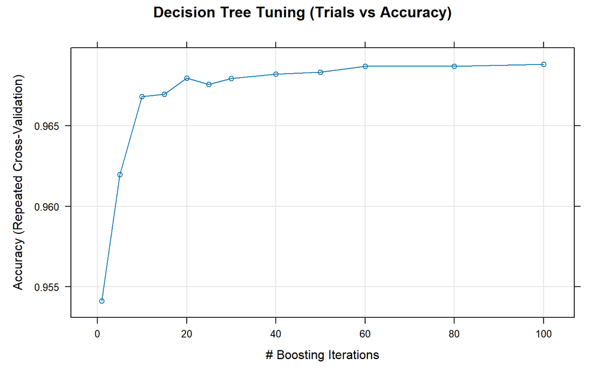

Decision Tree — accuracy across boosting trials.

```r
set.seed(7463)
grid_dt =expand.grid(model  = "tree",
                       trials = c(1, 5, 10, 15, 20, 25, 30, 40, 50, 60, 80, 100),
                       winnow = FALSE)

set.seed(7463)
dt_tuned =train(df_train[, -7], df_train[, 7],
                  method = "C5.0", trControl = ctrl_tune,
                  tuneGrid = grid_dt)

plot(dt_tuned, main = "Decision Tree Tuning (Trials vs Accuracy)")
```

> **Description:** Accuracy rises sharply as `trials` increases from 1, then plateaus. The optimum (`trials = 100) reflects the trade-off between bias and overfitting beyond this point, additional boosting iterations yield diminishing returns.

## 9.3 Naive Bayes Tuning

We tune the **Laplace correction** (`fL`) parameter, which smooths zero-frequency class–feature combinations.

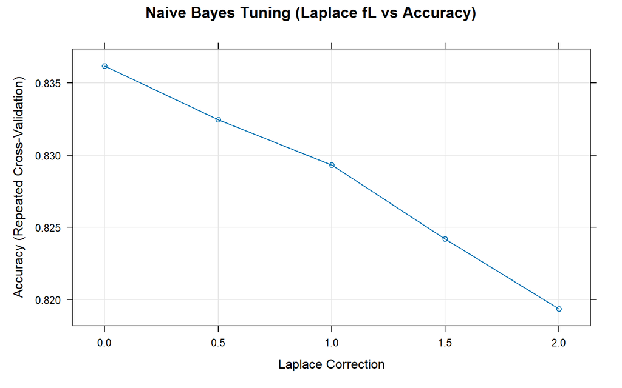

Naive Bayes — accuracy across Laplace correction values.

```r
set.seed(7463)
grid_nb =expand.grid(fL = c(0, 0.5, 1, 1.5, 2),
                       usekernel = FALSE, adjust = 1)

set.seed(7463)
nb_tuned =train(df_train[, -7], df_train$acceptability,
                  method = "nb", trControl = ctrl_tune,
                  tuneGrid = grid_nb)

plot(nb_tuned, main = "Naive Bayes Tuning (Laplace fL vs Accuracy)")
```

> **Description:** Accuracy is highest at `fL = 0` (no Laplace smoothing) and decreases monotonically as smoothing increases. This indicates that zero frequency events are not a problem in this dataset, so adding pseudocounts only blurs the probability estimates.

## 9.4 Logistic Regression Tuning

For multinomial logistic regression, we tune the **weight decay** parameter to regularise and prevent overfitting.

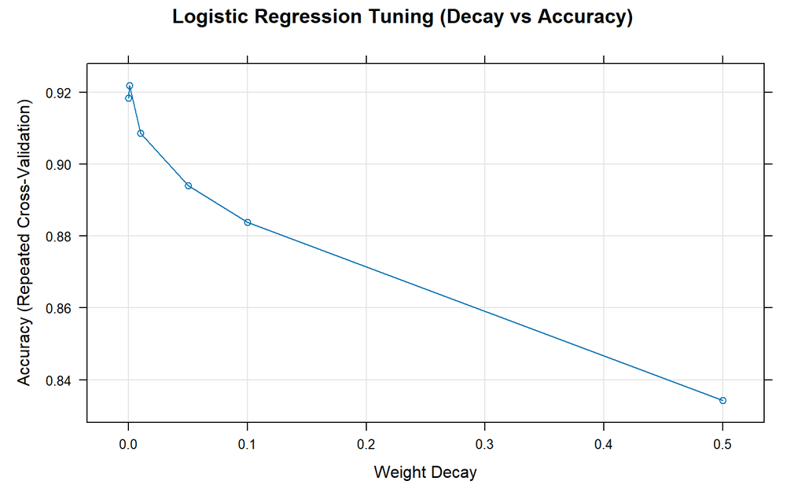

Logistic Regression — accuracy across weight decay values.

```r
set.seed(7463)
grid_lg =expand.grid(decay = c(0, 0.001, 0.01, 0.05, 0.1, 0.5))

set.seed(7463)
lg_tuned =train(df_train[, -7], df_train$acceptability,
                  method = "multinom", trControl = ctrl_tune,
                  tuneGrid = grid_lg, trace = FALSE)

plot(lg_tuned, main = "Logistic Regression Tuning (Decay vs Accuracy)")
```

> **Description:** A small amount of regularisation (`decay = 0.001`) slightly improves accuracy over no regularisation, but heavier decay rapidly degrades performance, suggesting the model needs most of its coefficient flexibility to separate four classes.

## 9.5 SVM (Linear) Tuning

For a linear SVM, the primary hyperparameter is **C** (cost). Lower C favours a wider margin; higher C penalises misclassifications more aggressively.

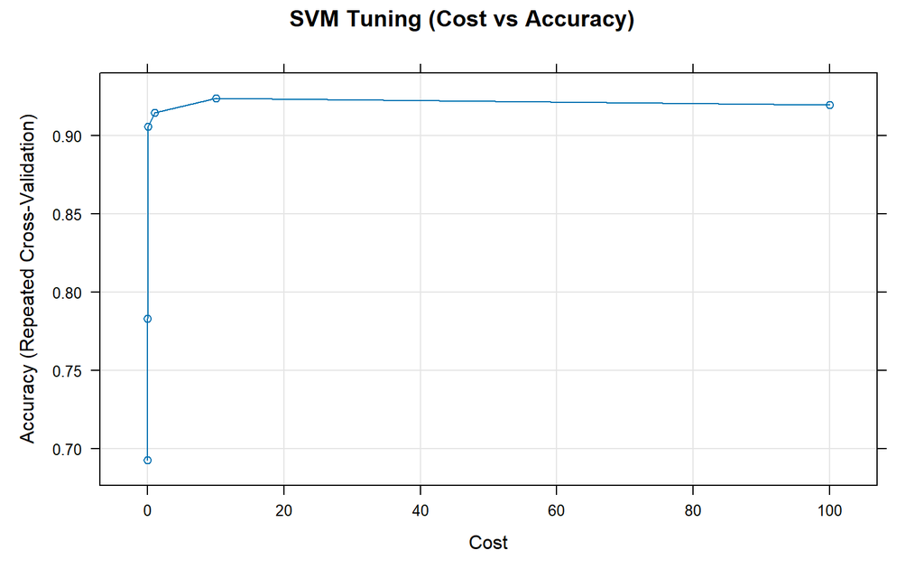

SVM — accuracy across cost values.

```r
set.seed(7463)
grid_svm =expand.grid(C = c(0.001, 0.01, 0.1, 1, 10, 100))

set.seed(7463)
svm_tuned =train(acceptability ~ ., data = df_train,
                   method = "svmLinear", trControl = ctrl_tune,
                   tuneGrid = grid_svm)

plot(svm_tuned, main = "SVM Tuning (Cost vs Accuracy)")
```

> **Description:** Accuracy climbs steadily from a low `C` value (wide margin, many misclassifications) up to `C = 10`, then drops slightly at `C = 100` as the model begins overfitting to the training data. The optimum at `C = 10` balances margin width and classification error.

## 9.6 Tuned Model Summary

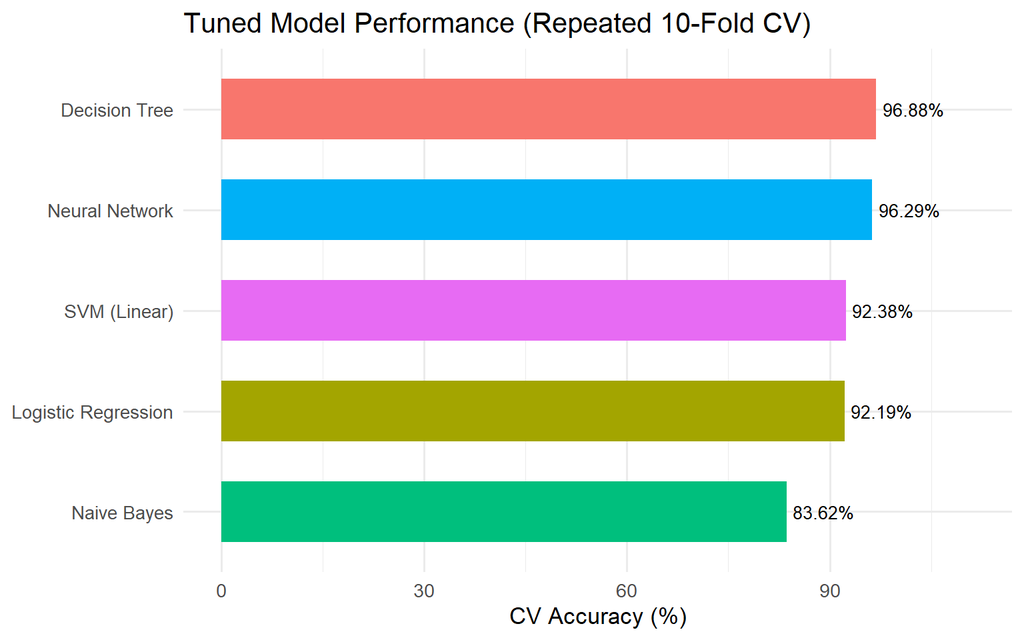

```r
tuned_results =data.frame(
  Model = c("Decision Tree", "Naive Bayes", "Logistic Regression",
            "Neural Network", "SVM (Linear)"),
  Best_Params = c(
    paste0("trials=", dt_tuned$bestTune$trials),
    paste0("fL=", nb_tuned$bestTune$fL),
    paste0("decay=", lg_tuned$bestTune$decay),
    paste0("decay=", nn_tuned$bestTune$decay),
    paste0("C=", svm_tuned$bestTune$C)
  ),
  CV_Accuracy = round(c(
    max(dt_tuned$results$Accuracy),
    max(nb_tuned$results$Accuracy),
    max(lg_tuned$results$Accuracy),
    max(nn_tuned$results$Accuracy),
    max(svm_tuned$results$Accuracy)
  ) * 100, 2)
)

ggplot(tuned_results, aes(y = reorder(Model, CV_Accuracy), x = CV_Accuracy, fill = Model)) +
  geom_col(width = 0.6) +
  geom_text(aes(label = sprintf("%.2f%%", CV_Accuracy)),
            hjust = -0.1, size = 3.5) +
  labs(title = "Tuned Model Performance (Repeated 10-Fold CV)",
       y = NULL, x = "CV Accuracy (%)") +
  theme_minimal(base_size = 13) +
  theme(legend.position = "none") +
  xlim(0, max(tuned_results$CV_Accuracy) * 1.15)
```

> **Description:** After tuning, the ranking is largely unchanged: Decision Tree leads at 96.9%, followed closely by Neural Network at 96.2%. SVM and Logistic Regression cluster around 92.4%, and Naive Bayes remains the weakest at 83.6%. Tuning yields only marginal gains, suggesting the default configurations were already near optimal for this dataset.

# 10 Conclusion

This report compared five classification algorithms on the UCI Car Evaluation dataset through a structured workflow exploratory data analysis, baseline modelling, cross-validation, feature selection, and hyperparameter tuning.

# 11 References

- UCI Machine Learning Repository, n.d. Car Evaluation. Available at: https://archive.ics.uci.edu/dataset/19/car+evaluation
- Katyal, A., Sharma, P.K. and Kannan, M., 2025. *Exploratory Data Analysis (EDA) on Undergraduate Data Science Students Through R Programming.*
- R Core Team (2024) *R: A Language and Environment for Statistical Computing*. Vienna: R Foundation for Statistical Computing. Available at: https://www.R-project.org/
- Kuhn, M. 2008. Building Predictive Models in R Using the caret Package. *Journal of Statistical Software*, 28(5).
- Kuhn, M., Weston, S., Culp, M., Coulter, N. and Quinlan, R., 2015. Package ‘C50’. CRAN, UTC.
- Wickham, H. (2016) *ggplot2: Elegant Graphics for Data Analysis*. 2nd edn. New York: Springer.
- Lantz, B. (2019) *Machine Learning with R*. 3rd edn. Birmingham: Packt Publishing.